# 01 - Inspection of data

Jens Linden

STATUS: Development

# 1 Management summary

- Load raw data
- Inspect data and perform initial data checks
- Preprocessing data
- Saving preprocessed data to file
  - Preprocessed review data table
  - Hotel master data table
  - Tag table
  - Table for tag statistics

The following hypotheses have been tested:

[output not shown]

# 2 Inits

Initialisations and loading of libraries required:

```r
rm(list=ls())   # clear all
graphics.off()  # close all
Sys.setenv(LANG = "en")
# Libs
# library(checkpoint) # Package management to avoid incompatibilities; not required when dockerized
# checkpoint('2017-10-01') # Use all packages as of date provided
library(data.table) # Efficient and fast data munging in R; just do it
options(datatable.auto.index=FALSE) # Bug fixing for v < 1.9.5
library(ggplot2) # Good quality plots
library(rprojroot) # Rroot folder management
ROOT <- find_root(has_file("PROJECT_ROOT_DIR"))
library(knitr) # Knitting R markdown reports
library(skimr) # Nice initial data overview
library(DataExplorer) # Nice summary statistics
library(leaflet) # Interacitve maps
library(sp) # Spatial data package
library(rworldmap) # Enables mapping of country level and gridded user datasets.
library(digest) # Hash computation
library(tidyr) # E.g. unnest data table for tags
library(stringr)
source(paste0(ROOT, "/02_code/lib.R"))
options(width = 100)
```

# 3 Settings

All settings for this reports at a single spot here>

```r
s <- list() # List for storing settings
s$file_inf <- paste0(ROOT, '/01_data/02_unzipped/ID01/Hotel_Reviews.csv') # Data file name for challenge
s$file_kag <- paste0(ROOT, '/01_data/02_unzipped/ID02/Hotel_Reviews.csv') # Data file name form Kaggle
```

# 4 Load data

```r
# Load inf data from csv
dt_inf <- fread(s$file_inf)
# Load Kaggle data from csv
dt_kag <- fread(s$file_kag)
```

# 5 Compare data sets

```r
dim(dt_inf)
```

```
## [1] 515738     17
```

```r
dim(dt_kag)
```

```
## [1] 515738     17
```

```r
# Same dimensions

# Identical?
all.equal(dt_inf, dt_kag)
```

```
## [1] TRUE
```

```r
# Yes, H1 correct.
```

Cleanup as data is identical.

```r
rev <- dt_inf
rm(list = c('dt_kag', 'dt_inf'))
```

# 6 Data type conversions

```r
# What re the coltypes
col_types(rev)
```

```
##                                            col     class
##  1:                              Hotel_Address character
##  2:               Additional_Number_of_Scoring   integer
##  3:                                Review_Date character
##  4:                              Average_Score   numeric
##  5:                                 Hotel_Name character
##  6:                       Reviewer_Nationality character
##  7:                            Negative_Review character
##  8:          Review_Total_Negative_Word_Counts   integer
##  9:                    Total_Number_of_Reviews   integer
## 10:                            Positive_Review character
## 11:          Review_Total_Positive_Word_Counts   integer
## 12: Total_Number_of_Reviews_Reviewer_Has_Given   integer
## 13:                             Reviewer_Score   numeric
## 14:                                       Tags character
## 15:                          days_since_review character
## 16:                                        lat   numeric
## 17:                                        lng   numeric
```

Loading via `data.table::fread` coerced nearly perfect, just date is required to be coerced.

## 6.1 Review_Date

```r
rev$Review_Date[1:10]
```

```
##  [1] "8/3/2017"  "8/3/2017"  "7/31/2017" "7/31/2017" "7/24/2017" "7/24/2017" "7/17/2017" "7/17/2017"
##  [9] "7/9/2017"  "7/8/2017"
```

```r
# Assume Review_Date is in format mm/dd/yyyy
rev[!grepl(pattern = '^\\d{1,2}\\/\\d{1,2}\\/\\d{4}', x = Review_Date)] # Yes
```

```
## Empty data.table (0 rows and 17 cols): Hotel_Address,Additional_Number_of_Scoring,Review_Date,Average_Score,Hotel_Name,Reviewer_Nationality...
```

```r
# Change data type to date
rev[, Review_Date := as.Date(Review_Date, format = '%m/%d/%Y')]
# Check
rev$Review_Date[1:5]
```

```
## [1] "2017-08-03" "2017-08-03" "2017-07-31" "2017-07-31" "2017-07-24"
```

```r
# Any NA created?
rev[is.na(Review_Date)] # No
```

```
## Empty data.table (0 rows and 17 cols): Hotel_Address,Additional_Number_of_Scoring,Review_Date,Average_Score,Hotel_Name,Reviewer_Nationality...
```

## 6.2 Review texts

Convert to lower case.

```r
rev[, Negative_Review := tolower(Negative_Review)]
rev[, Positive_Review := tolower(Positive_Review)]
```

# 7 Exploratary data analysis

Exploratory data analysis is the process to get to know the data, so that hypothesis can be generated and tested.

## 7.1 Initial inspection of data

```r
# Inspect first line
knitr::kable(rev[1])
```

| Hotel_Address | Additional_Number_of_Scoring | Review_Date | Average_Score | Hotel_Name | Reviewer_Nationality | Negative_Review | Review_Total_Negative_Word_Counts | Total_Number_of_Reviews | Positive_Review | Review_Total_Positive_Word_Counts | Total_Number_of_Reviews_Reviewer_Has_Given | Reviewer_Score | Tags | days_since_review | lat | lng |
| --- | --- | --- | --- | --- | --- | --- | --- | --- | --- | --- | --- | --- | --- | --- | --- | --- |
| s Gravesandestraat 55 Oost 1092 AA Amsterdam Netherlands | 194 | 2017-08-03 | 7.7 | Hotel Arena | Russia | i am so angry that i made this post available via all possible sites i use when planing my trips so no one will make the mistake of booking this place i made my booking via booking com we stayed for 6… | 397 | 1403 | only the park outside of the hotel was beautiful | 11 | 7 | 2.9 | [‘Leisure trip’, ‘Couple’, ‘Duplex Double Room’, ‘Stayed 6 nights’] | 0 days | 52.36058 | 4.915968 |

```r
# Quick overview
skim_with(numeric = list(hist = NULL),
          integer = list(hist = NULL)) # Do not show histogram as this is not displayed nicely within R markdown
skim(rev)
```

```
## Skim summary statistics
##  n obs: 515738
##  n variables: 17
##
## -- Variable type:character -------------------------------------------------------------------------------------------------------
##              variable missing complete      n min  max empty n_unique
##     days_since_review       0   515738 515738   6    7     0      731
##         Hotel_Address       0   515738 515738  34   96     0     1493
##            Hotel_Name       0   515738 515738   2   60     0     1492
##       Negative_Review     153   515585 515738   0 1964   849   323166
##       Positive_Review      11   515727 515738   0 1958   183   401607
##  Reviewer_Nationality       0   515738 515738   0   36   523      227
##                  Tags       0   515738 515738  11  213     0    55242
##
## -- Variable type:Date ------------------------------------------------------------------------------------------------------------
##     variable missing complete      n        min        max     median n_unique
##  Review_Date       0   515738 515738 2015-08-04 2017-08-03 2016-08-15      731
##
## -- Variable type:integer ---------------------------------------------------------------------------------------------------------
##                                    variable missing complete      n    mean      sd p0  p25  p50
##                Additional_Number_of_Scoring       0   515738 515738  498.08  500.54  1  169  341
##           Review_Total_Negative_Word_Counts       0   515738 515738   18.54   29.69  0    2    9
##           Review_Total_Positive_Word_Counts       0   515738 515738   17.78   21.8   0    5   11
##                     Total_Number_of_Reviews       0   515738 515738 2743.74 2317.46 43 1161 2134
##  Total_Number_of_Reviews_Reviewer_Has_Given       0   515738 515738    7.17   11.04  1    1    3
##   p75  p100
##   660  2682
##    23   408
##    22   395
##  3613 16670
##     8   355
##
## -- Variable type:numeric ---------------------------------------------------------------------------------------------------------
##        variable missing complete      n  mean   sd    p0   p25    p50   p75  p100
##   Average_Score       0   515738 515738  8.4  0.55  5.2   8.1   8.4    8.8   9.8
##             lat    3268   512470 515738 49.44 3.47 41.33 48.21 51.5   51.52 52.4
##             lng    3268   512470 515738  2.82 4.58 -0.37 -0.14  0.011  4.83 16.43
##  Reviewer_Score       0   515738 515738  8.4  1.64  2.5   7.5   8.8    9.6  10
```

```r
# Get introduced to your dataset using the DataExplorer package
introduce(rev)
```

```
##      rows columns discrete_columns continuous_columns all_missing_columns total_missing_values
## 1: 515738      17                8                  9                   0                 6700
##    complete_rows total_observations memory_usage
## 1:        512312            8767546    207844584
```

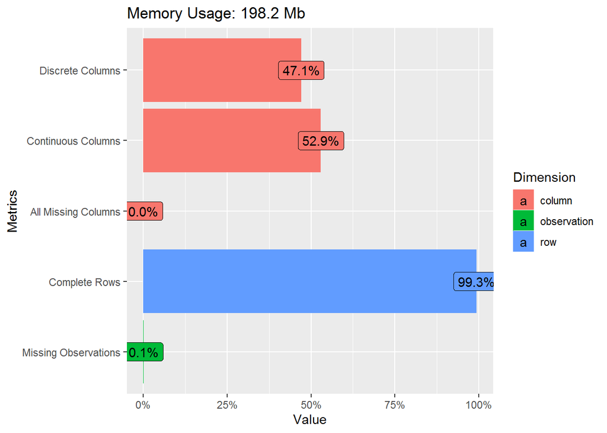

```r
plot_intro(rev)
```

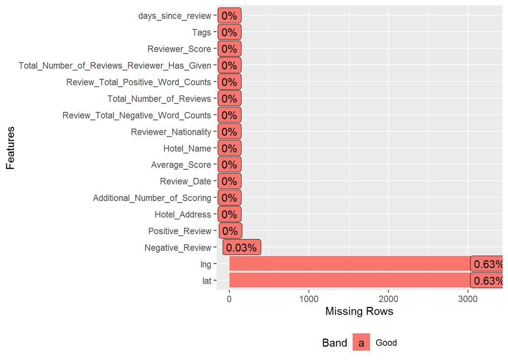

```r
plot_missing(rev)
```

## 7.2 Visualize distributions for all continuous features:

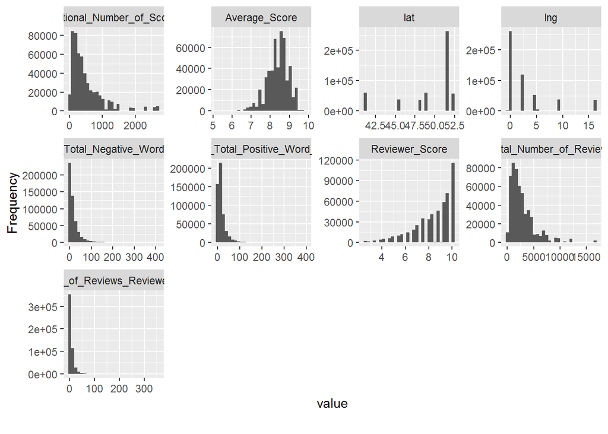

```r
plot_histogram(rev)
```

# 8 Amend dataset

## 8.1 Country

```r
rev[!is.na(lat), country := coords2country(cbind(lng, lat))]
# Inspect
rev[, .N, by = country]
```

```
##           country      N
## 1:    Netherlands  57214
## 2: United Kingdom 262301
## 3:         France  59546
## 4:           <NA>   3268
## 5:          Spain  59942
## 6:          Italy  37207
## 7:        Austria  36260
```

# 9 Hotel master data

## 9.1 Generate master data

```r
# Look at column names
names(rev)
```

```
##  [1] "Hotel_Address"                              "Additional_Number_of_Scoring"
##  [3] "Review_Date"                                "Average_Score"
##  [5] "Hotel_Name"                                 "Reviewer_Nationality"
##  [7] "Negative_Review"                            "Review_Total_Negative_Word_Counts"
##  [9] "Total_Number_of_Reviews"                    "Positive_Review"
## [11] "Review_Total_Positive_Word_Counts"          "Total_Number_of_Reviews_Reviewer_Has_Given"
## [13] "Reviewer_Score"                             "Tags"
## [15] "days_since_review"                          "lat"
## [17] "lng"                                        "country"
```

```r
# Pick hotel related columns
cols_hot <- c('Hotel_Name', 'Hotel_Address', 'country', 'lat', 'lng', 'Total_Number_of_Reviews')
# Inspect
rev[1:3, cols_hot, with = F]
```

```
##     Hotel_Name                                            Hotel_Address     country      lat
## 1: Hotel Arena s Gravesandestraat 55 Oost 1092 AA Amsterdam Netherlands Netherlands 52.36058
## 2: Hotel Arena s Gravesandestraat 55 Oost 1092 AA Amsterdam Netherlands Netherlands 52.36058
## 3: Hotel Arena s Gravesandestraat 55 Oost 1092 AA Amsterdam Netherlands Netherlands 52.36058
##         lng Total_Number_of_Reviews
## 1: 4.915968                    1403
## 2: 4.915968                    1403
## 3: 4.915968                    1403
```

```r
# Take only unique entries
hot <- unique(rev[, cols_hot, with = F])
hot[1:5]
```

```
##                          Hotel_Name
## 1:                      Hotel Arena
## 2:                 K K Hotel George
## 3:          Apex Temple Court Hotel
## 4: The Park Grand London Paddington
## 5:              Monhotel Lounge SPA
##                                                                             Hotel_Address
## 1:                               s Gravesandestraat 55 Oost 1092 AA Amsterdam Netherlands
## 2: 1 15 Templeton Place Earl s Court Kensington and Chelsea London SW5 9NB United Kingdom
## 3:          1 2 Serjeant s Inn Fleet Street City of London London EC4Y 1LL United Kingdom
## 4:                     1 3 Queens Garden Westminster Borough London W2 3BA United Kingdom
## 5:                                        1 3 Rue d Argentine 16th arr 75116 Paris France
##           country      lat        lng Total_Number_of_Reviews
## 1:    Netherlands 52.36058  4.9159683                    1403
## 2: United Kingdom 51.49189 -0.1949706                    1831
## 3: United Kingdom 51.51373 -0.1087512                    2619
## 4: United Kingdom 51.51422 -0.1809032                    4380
## 5:         France 48.87435  2.2897334                     171
```

```r
dim(hot)
```

```
## [1] 1494    6
```

```r
# Is combination of name and address uid?
sum(duplicated(hot[, .(Hotel_Name, Hotel_Address)])) # yes.
```

```
## [1] 0
```

Note, that there where 1,493 unique hotel addresses, 1,492 unique hotel names and now 1,494 unique combinations of name, address and geolocation. This implies, that there are still a few duplicates in the master data.

## 9.2 Check hotel name

Note that there are names with only two letters. Check:

```r
hot[, n_name := nchar(Hotel_Name)]
hot[n_name <= 7] # Inspect names with less than 8 characters
```

```
##     Hotel_Name                                                                Hotel_Address
##  1:    Belfast                                 10 avenue Carnot 17th arr 75017 Paris France
##  2:     Amp re                           102 Avenue de Villiers 17th arr 75017 Paris France
##  3:    L H tel                             13 rue des Beaux Arts 6th arr 75006 Paris France
##  4:    Bassano                                15 Rue de Bassano 16th arr 75016 Paris France
##  5:      Duret                                     30 Rue Duret 16th arr 75016 Paris France
##  6:       Le A                                    4 rue d Artois 8th arr 75008 Paris France
##  7:         41 41 Buckingham Palace Road Westminster Borough London SW1W 0PS United Kingdom
##  8:     Arioso                                  7 rue d Argenson 8th arr 75008 Paris France
##  9:       Cram                                     Aribau 54 Eixample 08011 Barcelona Spain
## 10:    The Ned                     Poultry 27 City of London London EC2R 8AJ United Kingdom
## 11:    MiHotel                    Via Dei Fontanili 26 Ripamonti Corvetto 20141 Milan Italy
##            country      lat        lng Total_Number_of_Reviews n_name
##  1:         France 48.87564  2.2938788                     337      7
##  2:         France 48.88486  2.2997023                     998      6
##  3:         France 48.85623  2.3351758                     224      7
##  4:         France 48.86906  2.2971078                     513      7
##  5:         France 48.87526  2.2866530                     167      5
##  6:         France 48.87238  2.3088663                     348      4
##  7: United Kingdom 51.49815 -0.1436492                     244      2
##  8:         France 48.87461  2.3167195                     218      6
##  9:          Spain 41.38805  2.1599602                     778      4
## 10: United Kingdom 51.51359 -0.0907833                     517      7
## 11:          Italy 45.44056  9.1921165                     319      7
```

Looks ok, aparat from name `41`

Inspect duplicates

```r
(dup_name <- unique(hot[duplicated(Hotel_Name), Hotel_Name]) )
```

```
## [1] "Hotel Regina"
```

```r
hot[Hotel_Name %in% dup_name] # Looks ok, just same name
```

```
##      Hotel_Name                                              Hotel_Address country      lat
## 1: Hotel Regina                 Bergara 2 4 Eixample 08002 Barcelona Spain   Spain 41.38589
## 2: Hotel Regina        Rooseveltplatz 15 09 Alsergrund 1090 Vienna Austria Austria 48.21633
## 3: Hotel Regina Via Cesare Correnti 13 Milan City Center 20123 Milan Italy   Italy 45.45949
##          lng Total_Number_of_Reviews n_name
## 1:  2.168165                    2775     12
## 2: 16.359554                    1948     12
## 3:  9.179511                     285     12
```

## 9.3 Check hotel address

```r
(dup_addr <- unique(hot[duplicated(Hotel_Address), Hotel_Address]) )
```

```
## [1] "8 Northumberland Avenue Westminster Borough London WC2N 5BY United Kingdom"
```

```r
hot[Hotel_Address %in% dup_addr] # Looks ok, maybe changed name or same building
```

```
##                              Hotel_Name
## 1:        The Grand at Trafalgar Square
## 2: Club Quarters Hotel Trafalgar Square
##                                                                 Hotel_Address        country
## 1: 8 Northumberland Avenue Westminster Borough London WC2N 5BY United Kingdom United Kingdom
## 2: 8 Northumberland Avenue Westminster Borough London WC2N 5BY United Kingdom United Kingdom
##         lat       lng Total_Number_of_Reviews n_name
## 1: 51.50693 -0.126012                    1592     29
## 2: 51.50693 -0.126012                    2494     36
```

## 9.4 Check geolocations

```r
hot[is.na(lat) | is.na(lng)]
```

```
##                                           Hotel_Name
##  1:                  Mercure Paris Gare Montparnasse
##  2:                     Holiday Inn Paris Montmartre
##  3:           Maison Albar Hotel Paris Op ra Diamond
##  4:                   NH Collection Barcelona Podium
##  5:                        City Hotel Deutschmeister
##  6:                                 Hotel Park Villa
##  7:              Fleming s Selection Hotel Wien City
##  8:                        Cordial Theaterhotel Wien
##  9:                              Hotel Daniel Vienna
## 10:                                     Roomz Vienna
## 11:                      Renaissance Barcelona Hotel
## 12: Austria Trend Hotel Schloss Wilhelminenberg Wien
## 13:                                    Hotel Advance
## 14:     Derag Livinghotel Kaiser Franz Joseph Vienna
```

[output cut: 39 more lines]

```r
# 17 hotels with missing geolocations
```

## 9.5 Is average hotel score unique for given hotel?

```r
dim(hot)
```

```
## [1] 1494    7
```

```r
dim(unique(rev[, c(cols_hot, 'Average_Score'), with = F]))
```

```
## [1] 1494    7
```

Yes, so take average score as part of master data.

```r
hot <- unique(rev[, c(cols_hot, 'Average_Score'), with = F])
```

## 9.6 Generate hotel id

```r
hot <- cbind(data.table(id_hot = 1:nrow(hot)), hot)
# Also add to review data
rev <- merge(rev,
             hot[, .(id_hot, Hotel_Name, Hotel_Address)],
             by = c("Hotel_Name", "Hotel_Address"),
             all.x = T)
```

## 9.7 Interactive visualization of hotel locations

Kindly borrowed from [Jason Liu](https://www.kaggle.com/jiashenliu/quick-visualization-of-data) using the awesome `leaflet` package.

```r
leaflet(data = hot) %>%
  addProviderTiles(providers$Stamen.TonerLite) %>%
  addMarkers(popup = ~Hotel_Address, clusterOptions = markerClusterOptions())
```

[interactive chart not shown]

There appear to be only dedicated locations:

- London
- Amsterdam
- Paris
- Milan
- Barcelona
- Vienna

## 9.8 Add city column and city center geolocations

```r
# Inspect
hot[, .N, by = country]
```

```
##           country   N
## 1:    Netherlands 105
## 2: United Kingdom 400
## 3:         France 455
## 4:           <NA>  17
## 5:          Spain 208
## 6:          Italy 162
## 7:        Austria 147
```

```r
# Map cities and geolocations (source https://www.latlong.net)
hot[country == "United Kingdom", c('city', 'city_lat', 'city_lng') := list('London', 51.509865, -0.118092)]
hot[country == "Netherlands", c('city', 'city_lat', 'city_lng') := list('Amsterdam', 52.37403, 4.88969)]
hot[country == "France", c('city', 'city_lat', 'city_lng') := list('Paris', 48.8566, 2.3522)]
hot[country == "Spain", c('city', 'city_lat', 'city_lng') := list('Barcelona', 41.3896, 2.1624)]
hot[country == "Italy", c('city', 'city_lat', 'city_lng') := list('Milan', 45.46427, 9.18951)]
hot[country == "Austria", c('city', 'city_lat', 'city_lng') := list('Vienna', 48.210033, 16.363449)]
```

## 9.9 Add number of reviews per hotel within dataset

```r
# Compute and add number of reviews column
hot <- merge(hot,
             rev[, .(n_reviews = .N), by = id_hot],
             by = 'id_hot')
```

# 10 Inspect review data

## 10.1 Review language

### 10.1.1 Detect language of negative review texts

```r
# Negative reviews
rev[, lang_neg_rev := cld2::detect_language(Negative_Review)]
rev[, .N, by = lang_neg_rev][order(N, decreasing = T)]
```

```
##     lang_neg_rev      N
##  1:           en 473449
##  2:         <NA>  41916
##  3:           pt     72
##  4:           fr     64
##  5:           da     29
##  6:           sv     26
##  7:           ht     26
##  8:           it     24
##  9:           nl     16
## 10:           es     14
## 11:           no     13
## 12:           de      9
## 13:           af      8
## 14:           eu      7
```

[output cut: 26 more lines]

```r
# Inspect
rev[lang_neg_rev == "de", Negative_Review] # Looks alright!
```

```
## [1] "raum sehr klein"
## [2] "d der wylan immer abgeschaltet war"
## [3] "very smull rooms very bad rooms richtig schlecht"
## [4] "keinerlei beanstandung"
## [5] "sauberkeit"
## [6] "teppichboden"
## [7] "der gestank vom abfluss im bad"
## [8] "t rknallen bis sp t in die nacht d mmung"
## [9] "matratzen zu weich"
```

How much in English?

```r
rev[lang_neg_rev == "en", .N] / nrow(rev) # 92%
```

```
## [1] 0.9180029
```

### 10.1.2 Detect language of positive review texts

```r
rev[, lang_pos_rev := cld2::detect_language(Positive_Review)]
```

How much in English?

```r
rev[lang_pos_rev == "en", .N] / nrow(rev) # 94%
```

```
## [1] 0.9394925
```

### 10.1.3 Reviews in different languages

```r
# How many?
rev[lang_neg_rev == "en" & lang_pos_rev != "en", .N]
```

```
## [1] 282
```

```r
# Inspect
rev[lang_neg_rev == "en" & lang_pos_rev != "en", .(Negative_Review, Positive_Review)][1]
```

```
##    Negative_Review Positive_Review
## 1:     no negative           funky
```

## 10.2 Time of review

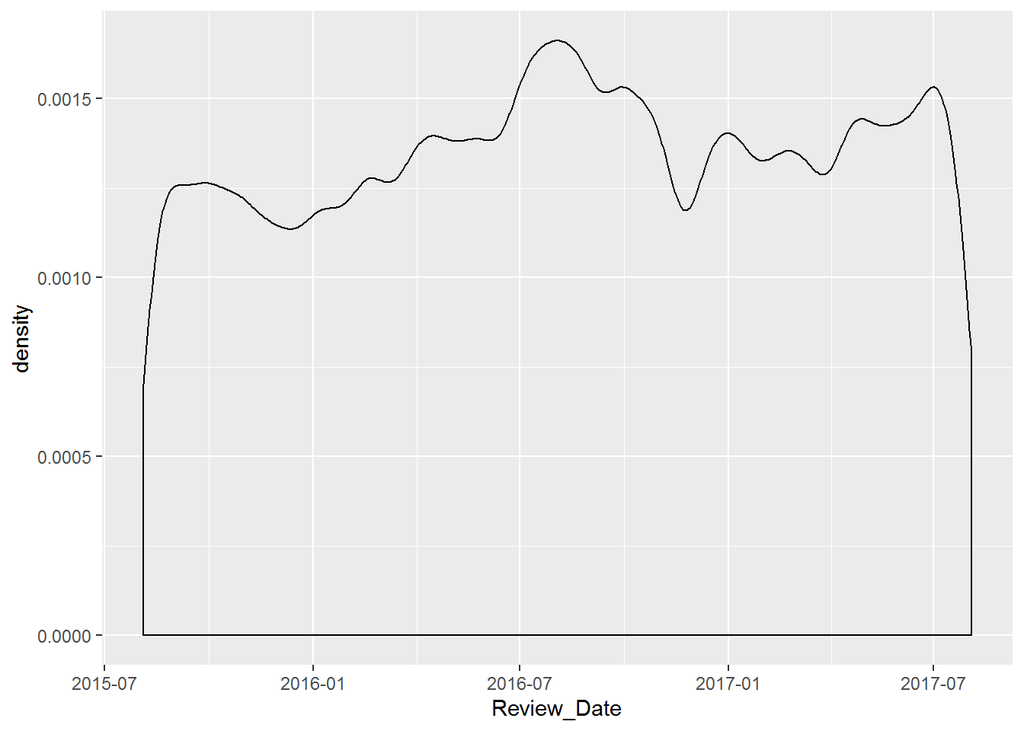

```r
ggplot(rev) + geom_density(aes(x = Review_Date))
```

```r
rev[, min(Review_Date)]
```

```
## [1] "2015-08-04"
```

```r
rev[, max(Review_Date)]
```

```
## [1] "2017-08-03"
```

More or less uniquely distributed over time

## 10.3 Duplicate reviews

Are there any duplicates?

```r
sum(duplicated(rev)) # Yes! 527
```

```
## [1] 527
```

```r
# Create hash per row (could simply use duplicated function but so easy to inspect and UID generated)
cols <- names(rev)
rev$input_hash <- apply(rev[ , cols , with = F] , 1 , paste , collapse = "-" )
rev$hash <- apply(rev[ , 'input_hash' , with = F] , 1 , digest , algo = "md5" )
rev$input_hash <- NULL
# Find duplicate hashes
dup_hash <- rev[duplicated(rev$hash), unique(hash)]
length(dup_hash) # 527
```

```
## [1] 527
```

```r
# Inspect example
rev[hash == dup_hash[1]]
```

```
##            Hotel_Name                                            Hotel_Address
## 1: Arthotel ANA Prime Sch nbrunner Stra e 41 05 Margareten 1050 Vienna Austria
## 2: Arthotel ANA Prime Sch nbrunner Stra e 41 05 Margareten 1050 Vienna Austria
##    Additional_Number_of_Scoring Review_Date Average_Score Reviewer_Nationality
## 1:                          144  2016-02-23           8.4                China
## 2:                          144  2016-02-23           8.4                China
##                                                                                                                                                     Negative_Review
## 1: price only includes room everything else is extra including coffee and tea even no kettle inside the room and cup of tea is 2 eur room is not really big just ok
## 2: price only includes room everything else is extra including coffee and tea even no kettle inside the room and cup of tea is 2 eur room is not really big just ok
##    Review_Total_Negative_Word_Counts Total_Number_of_Reviews
## 1:                                34                    1813
## 2:                                34                    1813
##                                   Positive_Review Review_Total_Positive_Word_Counts
## 1: good location very clean and modern nice staff                                10
## 2: good location very clean and modern nice staff                                10
##    Total_Number_of_Reviews_Reviewer_Has_Given Reviewer_Score
## 1:                                         26            7.5
## 2:                                         26            7.5
##                                                                            Tags days_since_review
## 1: [' Leisure trip ', ' Couple ', ' Standard Double Room ', ' Stayed 1 night ']           527 day
## 2: [' Leisure trip ', ' Couple ', ' Standard Double Room ', ' Stayed 1 night ']           527 day
##         lat      lng country id_hot lang_neg_rev lang_pos_rev                             hash
## 1: 48.19256 16.35761 Austria   1274           en           en a52f7ca8ad83eddb0399fc6b756f928f
## 2: 48.19256 16.35761 Austria   1274           en           en a52f7ca8ad83eddb0399fc6b756f928f
```

```r
# Remove dups
rev <- rev[!duplicated(rev)]
# Use hash as id column: rename
setnames(rev, 'hash', 'id_rev')
```

## 10.4 Plausicheck word counts

```r
# Inspect
rev[, .N, by = Review_Total_Negative_Word_Counts][order(N)]
```

```
##      Review_Total_Negative_Word_Counts      N
##   1:                               331      1
##   2:                               400      1
##   3:                               401      1
##   4:                               398      1
##   5:                               397      1
##  ---
## 398:                                 5  16788
## 399:                                 6  17726
## 400:                                 3  18126
## 401:                                 2  24630
## 402:                                 0 127757
```

```r
rev[Review_Total_Negative_Word_Counts == 0, .(Review_Total_Negative_Word_Counts, Negative_Review)][1:3]
```

```
##    Review_Total_Negative_Word_Counts Negative_Review
## 1:                                 0     no negative
## 2:                                 0     no negative
## 3:                                 0     no negative
```

```r
rev[Review_Total_Negative_Word_Counts == 2, .(Review_Total_Negative_Word_Counts, Negative_Review)][1:3]
```

```
##    Review_Total_Negative_Word_Counts Negative_Review
## 1:                                 2         nothing
## 2:                                 2         nothing
## 3:                                 2         nothing
```

```r
rev[Review_Total_Negative_Word_Counts == 3, .(Review_Total_Negative_Word_Counts, Negative_Review)][1:3]
```

```
##    Review_Total_Negative_Word_Counts Negative_Review
## 1:                                 3  was perfection
## 2:                                 3        all good
## 3:                                 3         nothing
```

```r
rev[Review_Total_Negative_Word_Counts == 4, .(Review_Total_Negative_Word_Counts, Negative_Review)][1:3]
```

```
##    Review_Total_Negative_Word_Counts         Negative_Review
## 1:                                 4          elevator shaky
## 2:                                 4 breakfast too expensive
## 3:                                 4      nothing to dislike
```

```r
# Roughly right, but not exact. is 'no negative' default value?
rev[, .N, by = Negative_Review][order(N, decreasing = T)][1:10]
```

```
##     Negative_Review      N
##  1:     no negative 127757
##  2:         nothing  21169
##  3:             n a   1814
##  4:            none   1500
##  5:                    849
##  6:  nothing really    655
##  7:      small room    568
##  8:       breakfast    545
##  9:        all good    544
## 10:   no complaints    523
```

```r
rev[is.na(Negative_Review), .N]
```

```
## [1] 153
```

```r
# What about positive?
rev[, .N, by = Positive_Review][order(N, decreasing = T)][1:10]
```

```
##        Positive_Review     N
##  1:        no positive 35904
##  2:           location 11927
##  3:         everything  3314
##  4:            nothing  1728
##  5:     great location  1685
##  6:       the location  1600
##  7:      good location  1495
##  8:          breakfast   795
##  9:     friendly staff   732
## 10: excellent location   639
```

## 10.5 Inspect hotels with most and fewest reviews respectively

```r
# How many reviews per hotel?
rev[, .N, by = id_hot][order(N)]
```

```
##       id_hot    N
##    1:   1019    8
##    2:   1383   10
##    3:    123   10
##    4:    242   12
##    5:    733   12
##   ---
## 1490:    690 3212
## 1491:   1272 3577
## 1492:   1481 4169
## 1493:    487 4256
## 1494:    187 4789
```

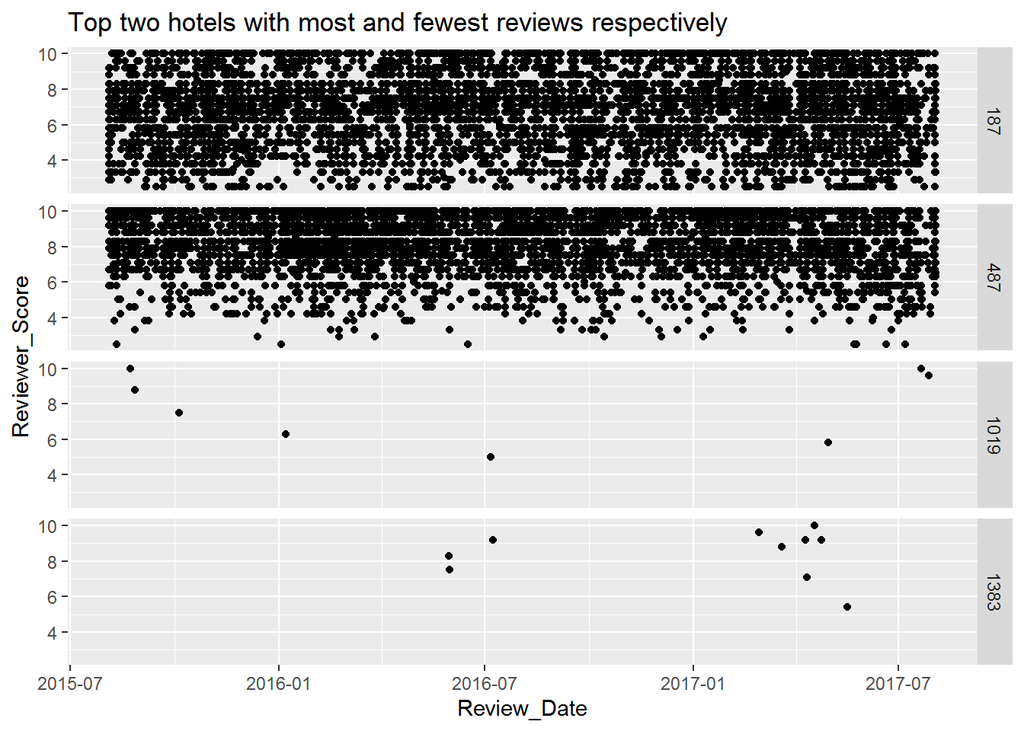

```r
# Inspect
# Inspect reviews for hotes with many and few reviews
ggplot(data = rev[id_hot %in% c(1019, 1383, 187, 487)],
       aes(x = Review_Date, y = Reviewer_Score)) +
  geom_point() +
  facet_grid("id_hot") +
  ggtitle("Top two hotels with most and fewest reviews respectively")
```

## 10.6 Are there hotels which are no longer open?

Generate stat data for reviews over time

```r
# Aggregate and join together
stat_rev <- merge(
  hot[, .(id_hot)],
  rev[Review_Date < '2016-01-01', .(n_b4_2016 = .N), by = id_hot],
  by = 'id_hot',
  all.x = T)
stat_rev <- merge(
  stat_rev,
  rev[Review_Date > '2017-01-01', .(n_after_2017 = .N), by = id_hot],
  by = 'id_hot',
  all.x = T)
# Any NAs?
inspect_na(stat_rev) # Yes, set to zero.
```

```
##             col n_na n_non_na n_inf n_fin
## 1:    n_b4_2016  136     1358     0  1494
## 2: n_after_2017    2     1492     0  1494
## 3:       id_hot    0     1494     0  1494
```

```r
stat_rev[is.na(n_b4_2016), n_b4_2016 := 0]
stat_rev[is.na(n_after_2017), n_after_2017 := 0]
inspect_na(stat_rev)
```

```
##             col n_na n_non_na n_inf n_fin
## 1:       id_hot    0     1494     0  1494
## 2:    n_b4_2016    0     1494     0  1494
## 3: n_after_2017    0     1494     0  1494
```

Inspect hotels, where there are no recent reviews

```r
stat_rev[n_after_2017 == 0] # Only two hotels, inspect
```

```
##    id_hot n_b4_2016 n_after_2017
## 1:      7       723            0
## 2:     80         7            0
```

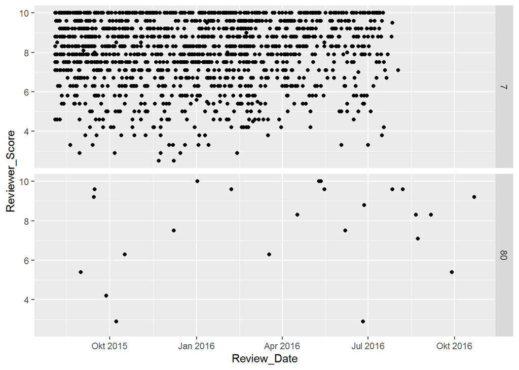

```r
ggplot(data = rev[id_hot %in% c(7, 80)],
       aes(x = Review_Date, y = Reviewer_Score)) +
  geom_point() +
  facet_grid("id_hot")
```

The hotel with id 7 seems indeed to have no recent reviews, whilst the hotel with id 80 simply appears to have very few reviews and is not necessarily closed at the end of the observed time range.

# 11 Tag data

## 11.1 Extract tag data from review data

Tags are given as nested elements with a 1:n relationship for review and tag. Generate data table in long format.

```r
# Split tag with respect to ','
rev[, tag_split := strsplit(rev[, Tags], ',')]
# Add number of tags to review data table
rev[, n_tags := str_count(Tags, ',') + 1]
# How many tags per review?
rev[, .N, by = n_tags][order(N)]
```

```
##    n_tags      N
## 1:      1      6
## 2:      2     85
## 3:      6    755
## 4:      3   5498
## 5:      4 211319
## 6:      5 297548
```

```r
# Extract nested list to data table in long format
tags <- unnest(rev[, .(id_rev, tag_split)])
# Inspect
print(tags)
```

```
##                                    id_rev                tag_split
##       1: 9af46ef4d7ed3c837dc0fd672dbc3b7f        [' Leisure trip '
##       2: 9af46ef4d7ed3c837dc0fd672dbc3b7f               ' Couple '
##       3: 9af46ef4d7ed3c837dc0fd672dbc3b7f  ' Superior Queen Room '
##       4: 9af46ef4d7ed3c837dc0fd672dbc3b7f      ' Stayed 1 night ']
##       5: 614888458f352152d1b786abf0b8b510        [' Leisure trip '
##      ---
## 2354212: 99aedbdb79cc5eda4b158677efe9386e     ' Stayed 3 nights ']
## 2354213: e36e77529dbbe2719deb0170dcee39b4        [' Leisure trip '
## 2354214: e36e77529dbbe2719deb0170dcee39b4               ' Couple '
## 2354215: e36e77529dbbe2719deb0170dcee39b4      ' penta Plus Room '
## 2354216: e36e77529dbbe2719deb0170dcee39b4     ' Stayed 3 nights ']
```

```r
# Clean up
setnames(tags, 'tag_split', 'tag') # Rename column
tags[, tag := gsub(pattern = ']', replacement = '', x = tag, fixed = T)] # Remove characters
tags[, tag := gsub(pattern = '[', replacement = '', x = tag, fixed = T)] # Remove characters
tags[, tag := gsub(pattern = "'", replacement = '', x = tag, fixed = T)] # Remove characters
tags[, tag := trim(tag)] # Remove leading and trailing blanks
tags[, tag := tolower(tag)]
# Inspect
print(tags)
```

```
##                                    id_rev                 tag
##       1: 9af46ef4d7ed3c837dc0fd672dbc3b7f        leisure trip
##       2: 9af46ef4d7ed3c837dc0fd672dbc3b7f              couple
##       3: 9af46ef4d7ed3c837dc0fd672dbc3b7f superior queen room
##       4: 9af46ef4d7ed3c837dc0fd672dbc3b7f      stayed 1 night
##       5: 614888458f352152d1b786abf0b8b510        leisure trip
##      ---
## 2354212: 99aedbdb79cc5eda4b158677efe9386e     stayed 3 nights
## 2354213: e36e77529dbbe2719deb0170dcee39b4        leisure trip
## 2354214: e36e77529dbbe2719deb0170dcee39b4              couple
## 2354215: e36e77529dbbe2719deb0170dcee39b4     penta plus room
## 2354216: e36e77529dbbe2719deb0170dcee39b4     stayed 3 nights
```